# Computing Residuals

## Computing Residuals

- Classic residuals for continuous random variables (e.g. linear model)

$$r = \text{observed} - \text{expected}$$

- Pearson residuals for GLMs, but shouldn’t really use them…

$$r = \frac{\text{observed} - \text{expected}}{\sqrt{\text{expected}}}$$

- Randomized Quantile Residuals
  - considered always an improvement for GLM
  - transform response variable to CDF $F(y|\widehat{\boldsymbol{\theta}})$
  - for discrete random variable draw uniform $[F(y-1|\widehat{\boldsymbol{\theta}}), F(y|\widehat{\boldsymbol{\theta}})]$
  - convert to real line by inverse standard normal
- One Step Ahead Residuals
  - RQR but account for correlation
  - Easy to do in RTMB
  - Becoming common in fisheries

## RTMB Sockeye Ricker

- Consider a model with a temporal random effect

$$\begin{align}
\log(R_i/S_i) & = \alpha_{s_i} + u_t + \beta_{s_i} S_i + \epsilon_i \\
\alpha_{s} & \sim N(\alpha_0, \eta^2) \\
\epsilon_i & \sim N(0, \sigma_{s_i}^2) \\
u_t & \sim N(\phi u_{t-1}, \gamma^2) \\
u_0 & \sim N(0, \gamma^2/(1-\phi^2)) \\
s & \in \{1,\ldots,n_{s}\}\\
t & \in \{1,\ldots, n_{y}\}
\end{align}$$

## Classic Residual Analysis

```r
library(RTMB)

sox$stock <- as.numeric(factor(sox$PopName))
nstocks <- max(sox$stock)
sox <- sox %>% mutate(time = yr - min(yr) + 1)
nyears <- max(sox$time)
minyear <- min(sox$yr)
sox$logRS <- log(sox$recruits/sox$spawners)

parameters <- list(
  alpha0 = runif(1, 2, 5),
  re = rnorm(nstocks),
  logbeta = runif(nstocks, 0, 1),
  logsigma = runif(nstocks, 3, 5),
  logsigma_re = runif(1, 0.5, 2),
  re_time = rnorm(nyears),
  logtphi = 0,
  logsigma_time = 0
)

negll <- function(pars){

  getAll(pars, sox, warn = FALSE)
  beta <- exp(logbeta)

  logRS <- OBS(logRS)

  sigma <- exp(logsigma)
  sigma_re <- exp(logsigma_re)
  sigma_time <- exp(logsigma_time)
  sigma_obs <- sigma[stock]
  phi <- 2*plogis(logtphi)-1

  alpha_stock <- re + alpha0
  ADREPORT(alpha_stock)

  mu <- alpha_stock[stock] + re_time[time] - beta[stock]*spawners_scaled
  logRS <- OBS(logRS)

  ## Use this for built in residuals
  ll <- dautoreg(re_time,phi=phi,scale=sqrt(sigma_time^2/(1-phi^2)), log=TRUE)

  ll <- ll + sum(dnorm(re, 0, sigma_re, log = TRUE))
  ll <- ll + sum(dnorm(logRS, mu, sigma_obs, log = TRUE))

  REPORT(mu)
  REPORT(re_time)
  REPORT(sigma_obs)

  return(-ll)
}

obj <- MakeADFun(func = negll, parameters = parameters, random = c("re", "re_time"), silent = TRUE)
fit <- nlminb(obj$par, obj$fn, obj$gr)
sox$expected <- obj$report()$mu
sox$sigma <- obj$report()$sigma_obs
sox <- sox %>%
  mutate(resid = logRS - expected) %>%
  mutate(resid_std = resid/sigma)
```

## Classic Residual Analysis (plot)

- Looks okay
- Conditional on random effects
- Checks if conditional error structure is correct
- Not about random effect structure

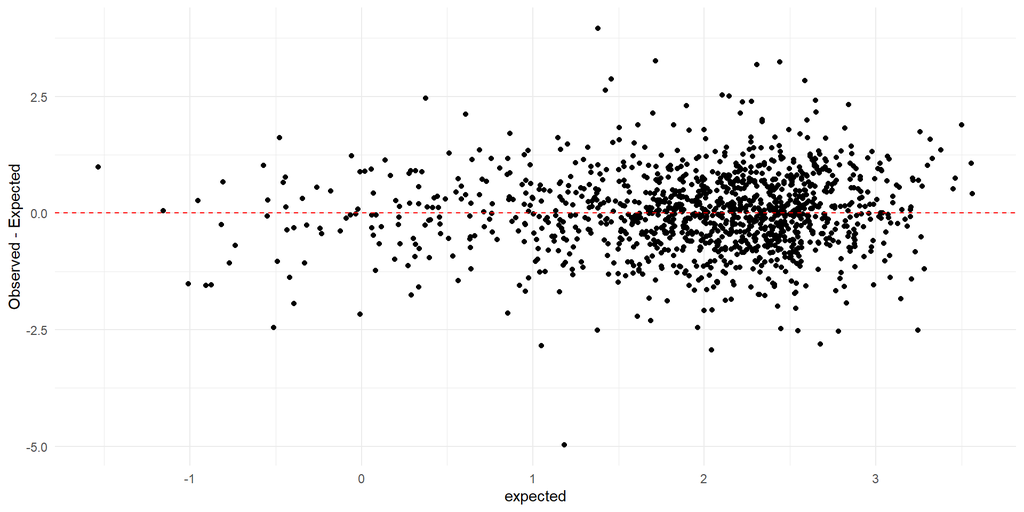

```r
ggplot(data = sox, aes(x = expected, y = resid)) +
  geom_point() + theme_minimal() +
  geom_hline(yintercept = 0, col = 'red', linetype = 2) +
  ylab("Observed - Expected")
```

```r
# qqnorm(sox$resid)
# qqline(sox$resid)
```

## Classic Residual Analysis (group)

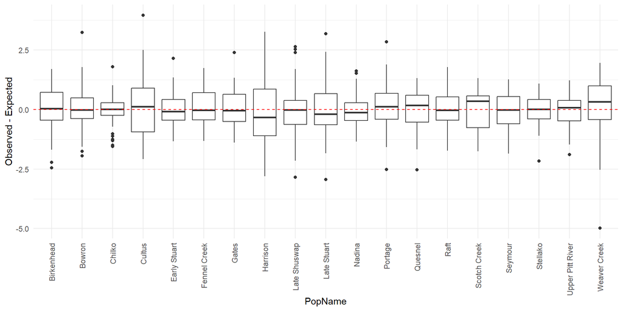

```r
ggplot(data = sox, aes(x = PopName, y = resid)) +
  geom_boxplot() + theme_minimal() +
  geom_hline(yintercept = 0, col = 'red', linetype = 2) +
  ylab("Observed - Expected") +
  theme(axis.text.x = element_text(angle = 90, vjust = 0.5, hjust = 1))
```

## Randomized Quantile Residuals

- Do we know the CDF of this distribution?
- If we don’t know the CDF then we can simulate to approximate it.
- Do we simulate to include the random effect uncertainty (unconditional)?
- In this case, equivalent to standardized residuals

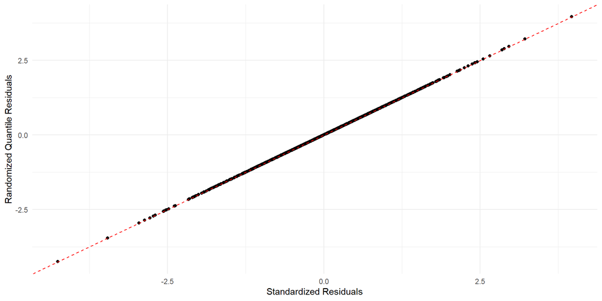

```r
## Known CDF
sox <- sox %>% mutate(cdf = pnorm(logRS, expected, sigma))

## Simulate for CDF
sims <- NULL
for( i in 1:1000 ){
 sims <- cbind(sims, rnorm(nrow(sox), sox$expected, sox$sigma))
}
## What proportion of simulations are less than observed?
sox$cdf_sim <- sapply(1:nrow(sox), FUN = function(i){(sum(sims[i, ] < sox$logRS[i]))/1000})

## RQR residual
sox$rqr <- qnorm(sox$cdf)
sox$rqr_sim <- qnorm(sox$cdf_sim)

ggplot(data = sox, aes(x = resid_std, y = rqr)) +
  geom_point() + theme_minimal() +
  geom_abline(intercept = 0, slope =1, col = 'red', linetype = 2) +
  xlab("Standardized Residuals") +
  ylab("Randomized Quantile Residuals")
```

## Classic Residual Analysis (time)

- Do the conditional residuals look independent?

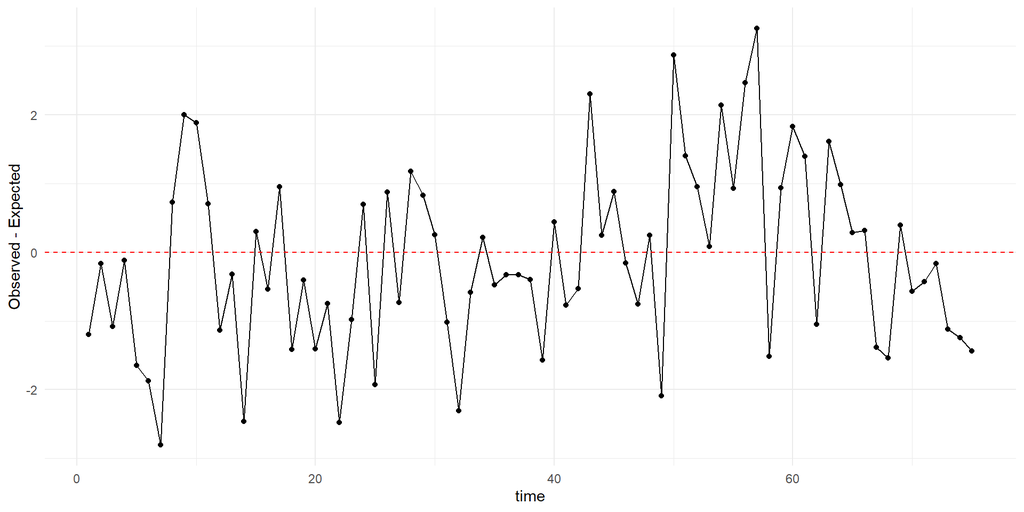

```r
ggplot(data = sox %>% filter(PopName == "Harrison"), aes(x = time, y = resid,)) +
  geom_point() + geom_line() + theme_minimal() +
  geom_hline(yintercept = 0, col = 'red', linetype = 2) +
  ylab("Observed - Expected")
```

## One Step Ahead Residuals

- We have assumed that the residuals are independent.
- If they aren’t, then you can get bad looking residuals even if the model is ‘correct’
- Instead, we can condition the residuals on the previous observation

$$(y_i - \widehat{y}_{i|i-1})/\widehat{\sigma}_{i|i-1}$$
- In this particular model, we have all observations within a year, conditional on the previous year’s random effect and then the stock specific random effect across years.

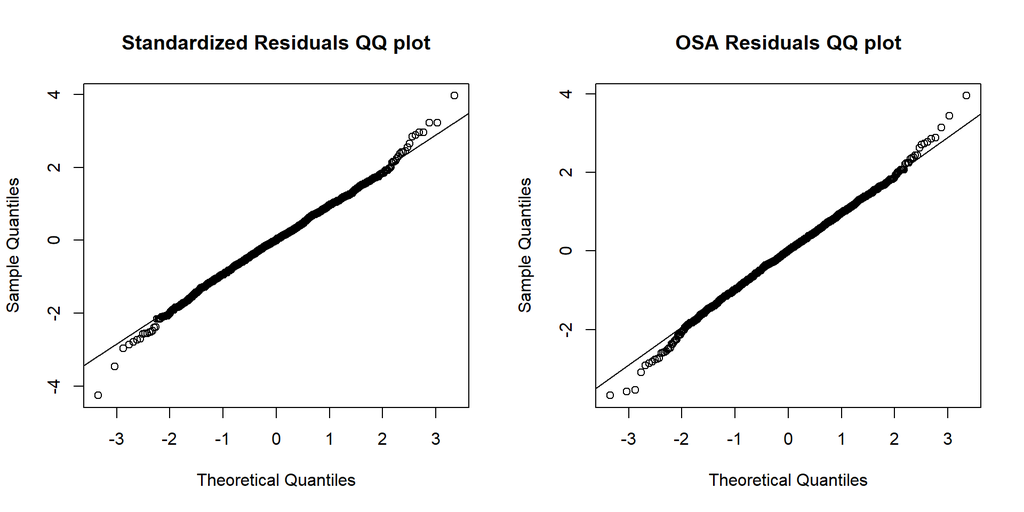

```r
resid_osa <- oneStepPredict (obj, trace = FALSE, method="oneStepGeneric")
sox$resid_osa <- resid_osa$residual

par(mfrow = c(1,2))
qqnorm(sox$resid_std, main = "Standardized Residuals QQ plot")
qqline(sox$resid_std)

qqnorm(resid_osa$residual, main = "OSA Residuals QQ plot")
qqline(resid_osa$residual)
```

## End of Module

- See *osa_multinomial.qmd* example for a multinomial distribution
- As our model becomes more complicated, we need to think harder about the residual analysis
- If you have non-normal data, always use RQR residuals, or OSA
- The more we want to code ‘custom’ the more work we need to also do for model checking, validation, and reporting